# 2. Regression and model validation

```r
library(tidyverse)
library(sandwich)
library(lmtest)
```

## Read the data

```r
analysisdata2 <- read_csv("data/learning2014.csv")
str(analysisdata2)
```

```
## spc_tbl_ [166 × 7] (S3: spec_tbl_df/tbl_df/tbl/data.frame)
##  $ gender  : chr [1:166] "F" "M" "F" "M" ...
##  $ Age     : num [1:166] 53 55 49 53 49 38 50 37 37 42 ...
##  $ attitude: num [1:166] 3.7 3.1 2.5 3.5 3.7 3.8 3.5 2.9 3.8 2.1 ...
##  $ deep    : num [1:166] 3.58 2.92 3.5 3.5 3.67 ...
##  $ stra    : num [1:166] 3.38 2.75 3.62 3.12 3.62 ...
##  $ surf    : num [1:166] 2.58 3.17 2.25 2.25 2.83 ...
##  $ Points  : num [1:166] 25 12 24 10 22 21 21 31 24 26 ...
##  - attr(*, "spec")=
##   .. cols(
##   ..   gender = col_character(),
##   ..   Age = col_double(),
##   ..   attitude = col_double(),
##   ..   deep = col_double(),
##   ..   stra = col_double(),
##   ..   surf = col_double(),
##   ..   Points = col_double()
##   .. )
##  - attr(*, "problems")=<externalptr>
```

#Data included survey variables from students, measuring attitudes towards statistics with 1-5 scael #Data set includes background characteristics like age and gender # There is also info about deep learning, strategic learning and surface learning

# Next, let’s draw some distirbutions

```r
data_long <- analysisdata2 %>% select(stra,surf,attitude) %>%
  pivot_longer(everything(), names_to = "Variable")
```

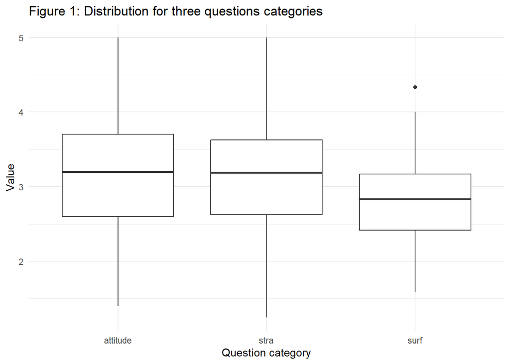

```r
ggplot(data_long, aes(x = Variable, y = value)) +
  geom_boxplot() +
  labs(title = "Figure 1: Distribution for three questions categories",
       x = "Question category",
       y = "Value") +
  theme_minimal()
```

##This figure shows the distribution for three variables. Median in these variables is around three. Next, lets look at age

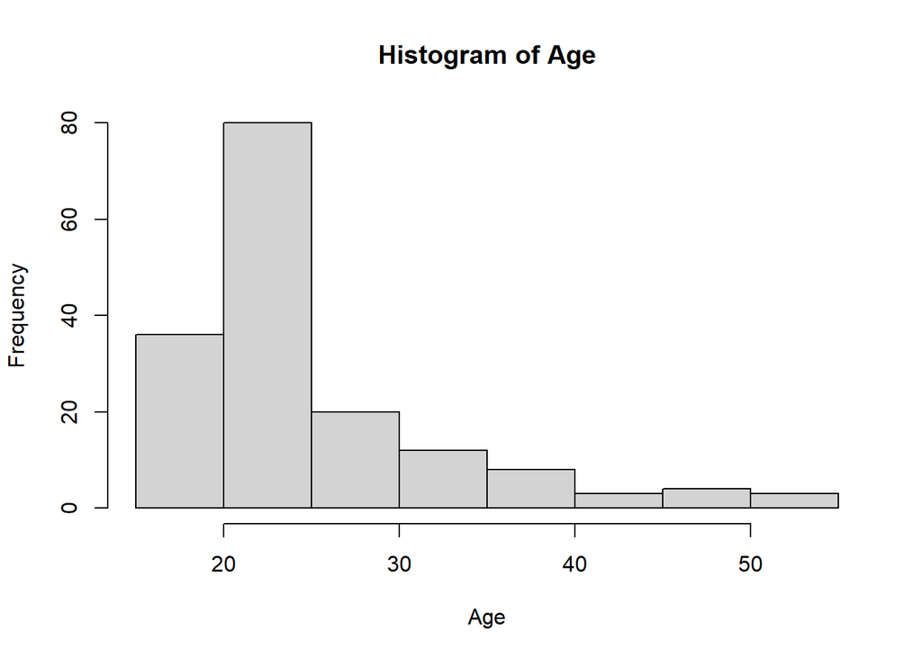

```r
  hist(analysisdata2$Age, main = "Histogram of Age", xlab = "Age", ylab = "Frequency")
```

#Next, regression

## Regression model

#Run model

```r
model <- lm(formula= Points ~ attitude + gender  + Age  + deep, data=analysisdata2)
summary(model)
```

```
##
## Call:
## lm(formula = Points ~ attitude + gender + Age + deep, data = analysisdata2)
##
## Residuals:
##      Min       1Q   Median       3Q      Max
## -17.3244  -3.3872   0.1616   3.9525  10.9188
##
## Coefficients:
##             Estimate Std. Error t value Pr(>|t|)
## (Intercept) 15.45100    3.43015   4.504 1.27e-05 ***
## attitude     3.65287    0.59677   6.121 6.83e-09 ***
## genderM     -0.31265    0.92068  -0.340    0.735
## Age         -0.07502    0.05374  -1.396    0.165
## deep        -0.59649    0.75259  -0.793    0.429
## ---
## Signif. codes:  0 '***' 0.001 '**' 0.01 '*' 0.05 '.' 0.1 ' ' 1
##
## Residual standard error: 5.321 on 161 degrees of freedom
## Multiple R-squared:  0.2049, Adjusted R-squared:  0.1851
## F-statistic: 10.37 on 4 and 161 DF,  p-value: 1.689e-07
```

T-test is used to test the significance of individual regression coefficient, it is calculated as a beta coefficient divided by standard error. T-test tells if the variable has a relatioship with the outcome in statistically meaningful way, if the coefficient is different from zero.

F-test tests if all the coefficients variable have statistically meaningful relationship (different from zero) together.

In the model above, only attitude had a statistically meaningful relatioship with points. Hence, I remove the other variables and run it again.

```r
model1 <- lm(formula= Points ~ attitude, data=analysisdata2)
summary(model1)
```

```
##
## Call:
## lm(formula = Points ~ attitude, data = analysisdata2)
##
## Residuals:
##      Min       1Q   Median       3Q      Max
## -16.9763  -3.2119   0.4339   4.1534  10.6645
##
## Coefficients:
##             Estimate Std. Error t value Pr(>|t|)
## (Intercept)  11.6372     1.8303   6.358 1.95e-09 ***
## attitude      3.5255     0.5674   6.214 4.12e-09 ***
## ---
## Signif. codes:  0 '***' 0.001 '**' 0.01 '*' 0.05 '.' 0.1 ' ' 1
##
## Residual standard error: 5.32 on 164 degrees of freedom
## Multiple R-squared:  0.1906, Adjusted R-squared:  0.1856
## F-statistic: 38.61 on 1 and 164 DF,  p-value: 4.119e-09
```

Based on outputs above one can conclude that only statistically significant coefficient in the specification is attitude (assuming homoskedastic errors!). On average one-unit increase in the scale of attitude increases points by roughly 3.5.

- t-value tests whether the coefficient is statistically significantly different from zero
- F-statistics tests whether all of the coefficient are different from zero (jointly)

##Next plots

# Residuals vs Fitted values

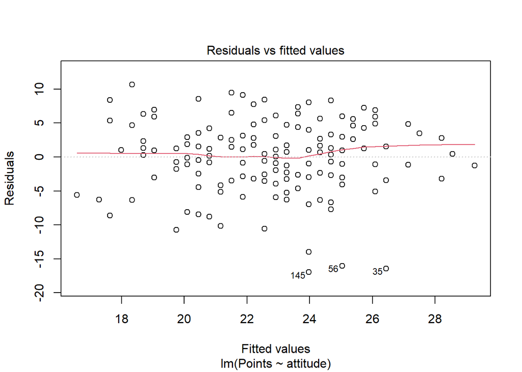

```r
plot(model1, which = 1,caption = "Residuals vs fitted values")
```

#Normal qq

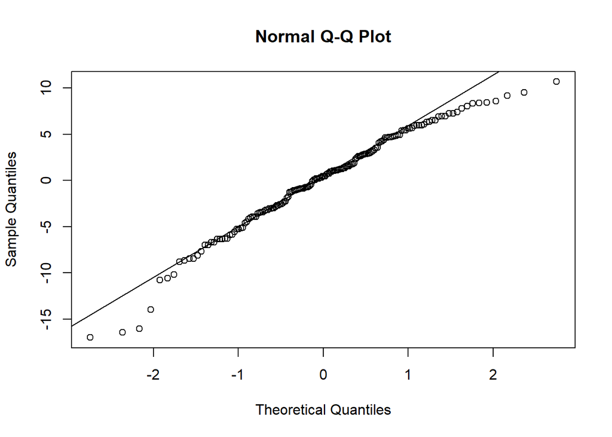

```r
qqnorm(model1$residuals)
qqline(model1$residuals)
```

#Residual vs leverage

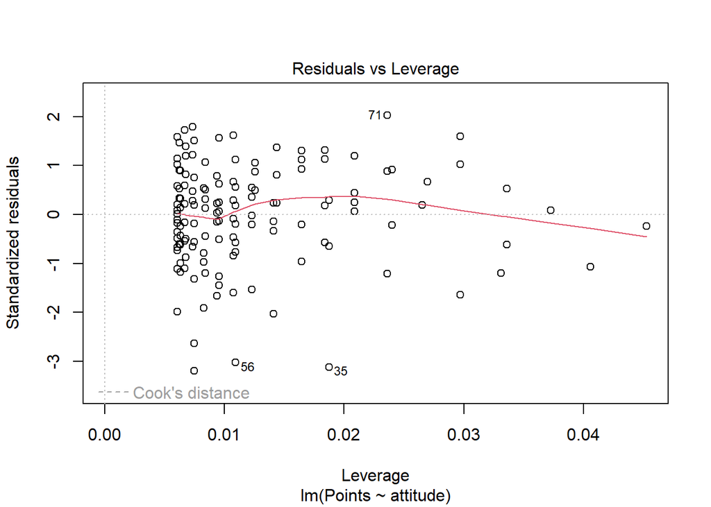

```r
plot(model1, which = 5)
```

Assumptions:

Linearity: The relationship between the independent variables and the dependent variable is linear. The model should capture a linear relationship between predictors and the outcome.

Independence of Errors (Residuals): The errors (residuals) in the model are independent of each other. There should be no correlation between consecutive residuals or any patterns in their distribution.

Homoscedasticity (Constant Variance of Errors): The variance of the errors should be constant across all levels of the independent variables. In other words, the spread of residuals should remain consistent across the range of predicted values.

Normality of Errors (Residuals): The residuals should follow a normal distribution. While the normality assumption is not necessary for unbiasedness, violations may affect the reliability of hypothesis tests and confidence interval

No Endogeneity: The independent variables are not correlated with the error term. If endogeneity exists (where a predictor is correlated with the error term), OLS estimates can be biased

##Based on the graphs linearity holds, errors might not be normally distributed but they are homoscedastic.